# EM Algorithm memo

Glidis

2019-06-21

最早一次还有印象的接触EM算法已经是在财大旁听黄勉data mining课的时候。记得当时自己只是把EM当做了一种求极值的方法，在认真看了下讲义上的推导后，觉得懂了，随后就丢脑后了。

得亏这几年来终于养成了保存和备份学习资料的习惯，今天一时兴起，找到了当时的PPT，然后一口老血就喷了出来。 PPT上写的是MM算法，EM算法只是提了一句`EM algorithm for missing data(Special Case of MM)`。 看来是自己记错了，不过脸皮厚点来说错的还不是很远。

最近一次碰到EM算法则是在今年4月底的外部培训上，讲师大概举了一个例子：如何在一堆身高数据中推测出男女的比例？并在有新的身高数据进来时，推测其性别。男性女性的身高都可以认为是服从高斯分布的，这个问题就非常适合用EM算法来解决。其他的例子如不均匀硬币抛掷问题。

忍不住吐槽一下，培训时关于EM讲的不清不楚的，某C*DN都是复制和粘贴，某乎略好一点，但也忽略掉了一些关键的地方，还是stackoverflow良心一些。培训后的几天里，翻了一些资料后，针对高斯混合分布，自己手动用R编写一个EM算法函数的尝试在失败了多次以后也终于成功了。隔了许多天后，想起这回事，在这里权且做个备忘吧。

## EM 算法原理

**应用场景**：知道分布函数，知道有几种分布（一般是同一分布但参数不同）。

例如，样本由两个参数不同的高斯分布混合而成，由身高数据推断男女各自的身高分布参数（假设高斯分布的情形下），进而给定新的身高数据时可以判断其为男女的概率。

假定是总体$X$是由$M=1,2,\cdots,m$个正态分布混合得来的。第$j \in M$个正态分布为$N(\mu_j, \sigma^2_j)$，样本${x_1, x_2, \cdots, x_n}$来自总体$X$，第$j$个正态分布贡献的比例为$\pi_j=P(x \in N_j)$，用MLE来表示即：

$$L = \prod_if(\mu_i,\sigma_i, \pi_i; x_i) = \prod_i ( \sum_j \pi_j \phi(\mu_j, \sigma_j; x_i|j))$$

有点像profile-MLE，即两套参数需要估计（共$n$个样本，$3M$个待估参数）。

取对数，由于$\pi_j$是概率，且对数函数是凹函数，根据Jansen不等式，有

$$\log L = \sum_i \log(\sum_j\pi_j\phi(\mu_j,\sigma_j;x_i) =\sum_i \log(E[\phi(x_i)]) \ge \sum_i E[\log(\phi(x_i))]$$

我们目地是最大化对数似然函数，得到参数矩阵$(\pi, \mu, \sigma)_{M,3}$，这对于上式的最右端，意味着只要尽量使等号成立即可。

但是，上式的写法并不太好，我们只简简单单用了一次Jansen不等式，对实际的求解并没有帮助。

可以看到，对数函数式左端log内有加权和，这样在求解必要条件一阶导数为0是比较困难的，而最右端的加权和是在log外面，可以想象到能玩花招也就在最右端项了：

$$\sum_{i=1}^n \sum_j \pi_j^{(k)} \log\left(\frac{\pi_j^{(k+1)}}{\pi_j^{(k+1)}}\phi(x_i; \mu_j^{(k)}, \sigma_j^{(k)})\right) \leq \sum_{i=1}^n\log\left(\sum_j\pi_j^{(k+1)}\frac{\pi_j^{(k)} \phi(x_i; \mu_j^{(k)}, \sigma_j^{(k)})}{\pi_j^{(k+1)}} \right) \ge \sum_{i=1}^n\sum_j\pi_j^{(k+1)}\log\left(\frac{\pi_j^{(k)} \phi(x_i; \mu_j^{(k)}, \sigma_j^{(k)})}{\pi_j^{(k+1)}} \right)$$

此时，有了$(\mu^{(k+1)}, \sigma^{(k+1)})$和上一步的副产品$\pi^{(k+1)}$，迭代可以进行下去，直至收敛。

**注意1：**

- 关于Jansen不等式部分，我们注意到第一个$\leq$其实是$<$，这是因为对于第$i$个样本，对于不同的高斯分布，其对应的likelihood是不同的。第一个$\leq$是对所有的$\pi_j^{(k+1)}$成立，然而第二个不等式是$\ge$，为了保证目标函数值递增，这里只能想办法让$\ge$变为$=$。而且可以验证当等号成立时
  $$\sum_{i=1}^n\sum_j\pi_j^{(k+1)}\log(\tilde{\phi}(x_i; \mu_j^{(k)}, \sigma_j^{(k)})) = \sum_{i=1}^n\sum_j\pi_{i,j}^{(k+1)}\log(\tilde{\phi}(x_i; \mu_j^{(k)}, \sigma_j^{(k)})) = \max_{\sum_j \pi_{i,j} = 1} \sum_{i=1}^n\sum_j\pi_{i,j}^{(k+1)}\log\left(\frac{\pi_j^{(k)} \phi(x_i; \mu_j^{(k)}, \sigma_j^{(k)})}{\pi_{i,j}^{(k+1)}} \right)$$
- 为什么会收敛？我们先再用土法再分析一下。我们的目地是使得
  $$\sum_i \sum_j \log\left(\pi_j^{(k)} \phi(x_i; \mu_j^{(k)}, \sigma_j^{(k)})\right) \leq \sum_i \sum_j \log\left(\pi_j^{(k+1)} \phi(x_i; \mu_j^{(k+1)}, \sigma_j^{(k+1)})\right).$$
  一步一步来，
  $$\begin{align}
  \sum_{i=1}^n \sum_j \log\left(\pi_j^{(k)} \phi(x_i; \mu_j^{(k)}, \sigma_j^{(k)})\right) & =
  \sum_{i=1}^n\sum_j\pi_{i,j}^{(k+1)}\log\left(\frac{\pi_j^{(k)} \phi(x_i; \mu_j^{(k)}, \sigma_j^{(k)})}{\pi_{i,j}^{(k+1)}} \right) \\
  & \leq \sum_{i=1}^n\sum_j\pi_{i,j}^{(k+1)}\log\left(\frac{\pi_j^{(k)} \phi(x_i; \mu_j^{(k+1)}, \sigma_j^{(k+1)})}{\pi_{i,j}^{(k+1)}} \right) \\
  & = \sum_{i=1}^n \sum_j \pi_{i,j}^{(k+1)} \phi(x_i; \mu_j^{(k+1)}, \sigma_j^{(k+1)}) +
  \sum_{i=1}^n \sum_j \pi_{i,j}^{(k+1)}\log\left(\frac{\pi_j^{(k)}}{\pi_{i,j}^{(k+1)}} \right) \\
  & \leq \sum_{i=1}^n \sum_j \pi_{i,j}^{(k+1)} \phi(x_i; \mu_j^{(k+1)}, \sigma_j^{(k+1)}) +
  \sum_{i=1}^n \sum_j \pi_{i,j}^{(k+1)}\log\left(\frac{\pi_j^{(k+1)}}{\pi_{i,j}^{(k+1)}} \right) \\
  & = \sum_{i=1}^n\sum_j\pi_{i,j}^{(k+1)}\log\left(\frac{\pi_j^{(k+1)} \phi(x_i; \mu_j^{(k+1)}, \sigma_j^{(k+1)})}{\pi_{i,j}^{(k+1)}} \right) \\
  & \leq \sum_{i=1}^n \sum_j \log\left(\pi_j^{(k+1)} \phi(x_i; \mu_j^{(k+1)}, \sigma_j^{(k+1)})\right).
  \end{align}$$
  第1个$=$是使得Jansen不等式中等号成立情形，第1个$\leq$是关于$(\mu, \sigma)$求最大值，第3个$\leq$来自Jansen不等式，第2个$\leq$则来自于$\pi_j^{(k+1)} = \frac{1}{n}\sum_{i=1}^n\pi_{i,j}^{(k+1)}$是以下问题的最优解
  $$\max_{\pi_1, \ldots, \pi_M}\sum_{i=1}^n \sum_{j=1}^M \pi_{i,j}^{(k+1)}\log\left(\frac{\pi_j} {\pi_{i,j}^{(k+1)}} \right) \\
  s.t. \quad \pi_j \ge 0 \quad for \quad j = 1, \ldots, M \\
  \sum_j \pi_j = 1$$

## R代码实现

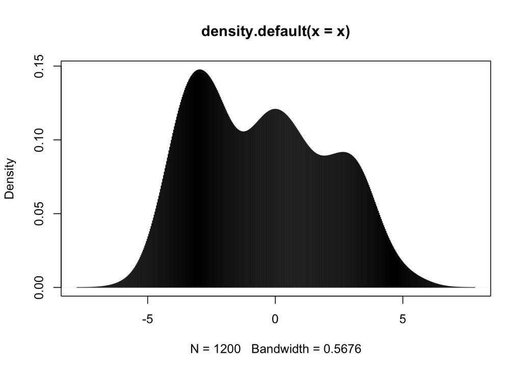

```r
## Expectation Maximize
## Gaussian Mix Model
##

# generating data

x1 <- rnorm(300, 3, 1)
x2 <- rnorm(400, 0, 1)
x3 <- rnorm(500, -3, 1)
x <- c(x1,x2,x3)
plot(density(x), type = 'h')
```

```r
## EM functions
get_theta <- function(dat, k, mu_ini = runif(k, -5, 5),
                   sig_ini = runif(k, 1, 10), pi_ini = rep(1, k)/k){
  n <- length(dat)
  M_den  <- mapply(function(v1,v2)dnorm(dat, v1, v2), mu_ini, sig_ini)*
                           (matrix(1,n,1)%*%matrix(pi_ini, nrow = 1))
  M_norm <- t(apply(M_den, 1, function(x)x/sum(x)))
  theta_new <- apply(M_norm, 2, mean)
  #ll_0 <- sum(log(M_den/M_norm)*M_norm)
  ll_0 <- sum(log(rowSums(M_den)))
  return(list(tht = theta_new, Pmat = M_norm, ll_0=ll_0))
}

get_musig <- function(dat, Pmat){
  k <- ncol(Pmat)
  dv <- matrix(dat, nrow = 1)
  mu_new <- dv %*% Pmat/colSums(Pmat)
  esq <- (matrix(1, nrow = k, ncol = 1) %*% dv -  as.vector(mu_new))^2
  sig_new <- diag(esq %*% Pmat)/colSums(Pmat)
  return(list(mu = as.vector(mu_new), sig = sqrt(sig_new)))
}

## 迭代
k <- 3
theta <- get_theta(x,k)
ll_0 <- theta$ll_0
i <- 0
gap <- 10
tol <- 1e-4
while (i <= 1000 && gap > tol) {
  new_musig <- get_musig(x, theta$Pmat)
  theta <- get_theta(x, k, new_musig$mu, new_musig$sig, theta$tht)
  ll_1 <- theta$ll_0
  gap <- ll_1 - ll_0
  ll_0 <- ll_1
  i <- i + 1
  if(i >= 1000 || gap <= tol){
    print(data.frame(theta=theta$tht, mu = new_musig$mu, sig = new_musig$sig))
  }
}
```

```
##       theta          mu       sig
## 1 0.3119628 -0.03301521 0.9768111
## 2 0.2669549  2.81863934 1.1260521
## 3 0.4210823 -3.04057952 0.9913788
```

也可以使用开源的R包来实现

```r
library(mixtools)
res <- normalmixEM(x, c(0.2,.3, .5), runif(3, -5, 5), runif(3, 1, 10))
```

```
## number of iterations= 601
```

```r
print(data.frame(theta = res$lambda, mu = res$mu, sig = res$sigma))
```

```
##       theta          mu       sig
## 1 0.2691078  2.80656558 1.1317553
## 2 0.4225129 -3.03576517 0.9939150
## 3 0.3083794 -0.03514202 0.9656884
```

**注意2：** 在实际问题中，EM算法并不总是收敛的，有可能落进局部解。例如，以上例子中，我们将方差变大，结果将不在收敛。

```r
res <- normalmixEM(c(rnorm(300, -3, 5), rnorm(400, 0, 2), rnorm(500, 3, 4)),
                   c(0.2,.3, .5), runif(3, -5, 5), runif(3, 1, 10))
```

```
## WARNING! NOT CONVERGENT!
## number of iterations= 1000
```

```r
print(data.frame(theta = res$lambda, mu = res$mu, sig = res$sigma))
```

```
##       theta         mu      sig
## 1 0.3858549 -0.6938752 5.619872
## 2 0.4809282  1.2976450 3.197854
## 3 0.1332170 -0.2032200 1.175734
```

## 专业的广义的EM收敛性证明

详细内容参考**ESLII**中*The EM Algorithm in General*节。 记$\mathbf{Z}$为观测样本，$\mathbf{Z}^m$为隐变量，即一系列的dummy，表示某样本是否属于某分布。另记$\mathbf{T} = (\mathbf{Z}, \mathbf{Z}^m)$，$\theta$为待估参数，既包含每个分布中的参数，还包含分布之间的混合比例。那么有